# Combining Predictors

Tejus

15/11/2020

### Key ideas

- You can combine different classifiers by averaging/voting (Boosting classfier + RF + lm)
- Combining classifiers improves accuracy but reduces interpretability
- Boosting, bagging, and random forests are variants on this theme with same classfier used

### Basic intuition - majority vote

Suppose we have 5 completely independent classifiers

If accuracy is 70% for each:

- $10\times(0.7)^3(0.3)^2 + 5\times(0.7)^4(0.3)^2 + (0.7)^5$
- 83.7% majority vote accuracy

With 101 independent classifiers * 99.9% majority vote accuracy

### Approaches for combining classifiers

1. Bagging, boosting, random forests
- Usually combine similar classifiers
2. Combining different classifiers
- Model stacking
- Model ensembling

### Model Stacking

- Example with Wage data

**Create training, test and validation sets**

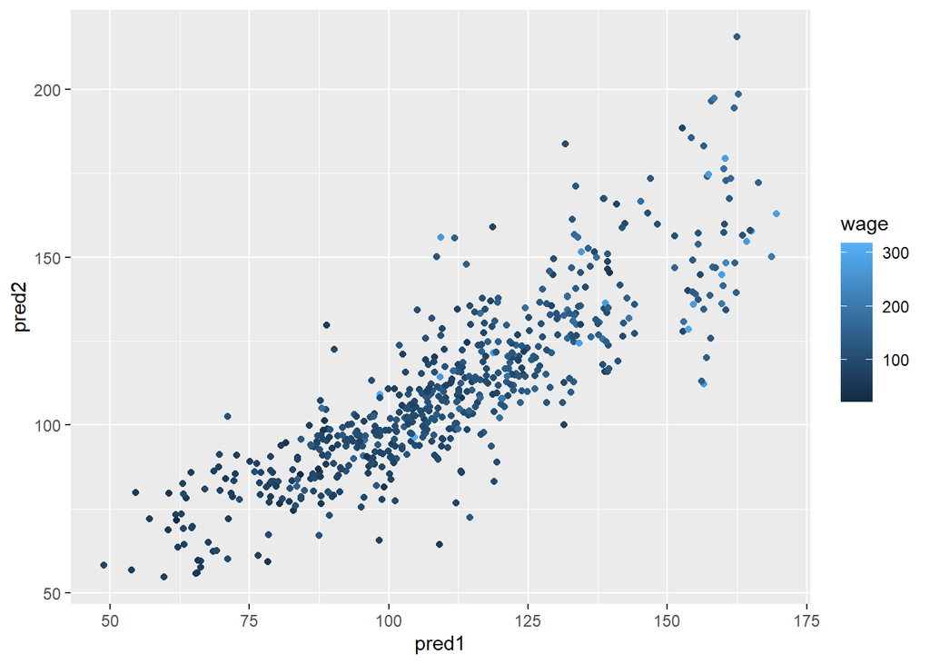

```r
Wage <- subset(Wage,select=-c(logwage))
# Create a building data set and validation set
inBuild <- createDataPartition(y=Wage$wage,
                              p=0.7, list=FALSE)
validation <- Wage[-inBuild,]; buildData <- Wage[inBuild,]

inTrain <- createDataPartition(y=buildData$wage,
                              p=0.7, list=FALSE)
training <- buildData[inTrain,]; testing <- buildData[-inTrain,]

## Build two different models
mod1 <- train(wage ~.,method="glm",data=training)
mod2 <- train(wage ~.,method="rf",
              data=training,
              trControl = trainControl(method="cv"),number=3)

## Predict on the testing set
pred1 <- predict(mod1,testing); pred2 <- predict(mod2,testing)
qplot(pred1,pred2,colour=wage,data=testing)
```

- Neither of them perfectly correlate to the `Wage` variable. Also they’re not perfectly on the diagonal

#### Fit a model that combines predictors

```r
predDF <- data.frame(pred1,pred2,wage=testing$wage)
combModFit <- train(wage ~.,method="gam",data=predDF)
combPred <- predict(combModFit,predDF)
```

- Reduced the testing error

```r
sqrt(sum((pred1-testing$wage)^2)) # model 1
```

```
## [1] 904.5118
```

```r
sqrt(sum((pred2-testing$wage)^2)) # model 2
```

```
## [1] 946.5273
```

```r
sqrt(sum((combPred-testing$wage)^2)) # model 1 + 2
```

```
## [1] 893.7795
```

#### Predict on validation data set

```r
pred1V <- predict(mod1,validation); pred2V <- predict(mod2,validation)
predVDF <- data.frame(pred1=pred1V,pred2=pred2V)
combPredV <- predict(combModFit,predVDF)
```

- Reduced the validation error

```r
sqrt(sum((pred1V-validation$wage)^2)) # model 1
```

```
## [1] 978.3105
```

```r
sqrt(sum((pred2V-validation$wage)^2)) # model 2
```

```
## [1] 1016.569
```

```r
sqrt(sum((combPredV-validation$wage)^2)) # model 1 + 2
```

```
## [1] 976.501
```

## Notes and further resources

- Even simple blending can be useful
- Typical model for binary/multiclass data
  - Build an odd number of models
  - Predict with each model
  - Predict the class by majority vote
- This can get dramatically more complicated
  - Simple blending in caret: caretEnsemble (use at your own risk!)
  - Wikipedia [ensemlbe learning](http://en.wikipedia.org/wiki/Ensemble_learning)